# DATS 6101 Project II: Understanding Environmental Vulnerabilty

Sadaf Asrar, Nelson Foster,Qianyi Huang, & Zhengzheng Yu

April 30, 2017

1. Research Question

Initial research question

What environmental and economic factors contribute to rising water levels in low elevation coastal zones (LECZ)? Specifically, can we predict when an LECZ will go under water?

The question was too broad and had to be narrowed down to a single LECZ for time series prediction. We considered Bangladesh as a case study and identified plenty of prior research on this topic that uses robust empirical time series models to predict the rising sea level in Bangladesh.

Given a lot of prior research has been conducted on this topic, we decided to revise the research question to identify factors that contribute to the environment’s ability to withstand external shocks.

Revised research question

What factors contribute to the vulnerability of the natural environment to sustain natural and human-made disasters? Specifically, what factors contribute to a country’s score on the Environmental Vulnerability Index (EVI)?

Why use EVI?

Prepared by South Pacific Applied Geoscience Commission (SOPAC), UNEP, and other partners, the EVI is an aggregated indicator made up of 50 sub-indicators and sub-indices which provides an estimation of the ability of a country or a region to sustain future environmental and ecological disasters (Kaly, Pratt, Mitchell, 2004).

Overall EVI Scale is as follows: i. Extremely vulnerable: 365+; ii. Highly vulnerable: 315-364; iii. Vulnerable: 265-314; and iv. At risk: 215-264 v. Resilient :<264. (Kaly, U.L.; C.R. Pratt; J. Mitchell, 2004).

2. Prior Research

Qualitative research

Authored by UN ISDR, “Environment and Vulnerability: Emerging Prospects” identified 5 pathways that link the natural environment to the ability to sustain disaster, and then connect the management of the natural environment to ability to minimize vulnerability to future disasters. The pathways are:  
a. Natural disasters can be brought on human action b. The health of the ecosystem can serve as a defense barrier from natural disasters c. Communities in depleted or marginalized ecosystems have less resistance to future environmental shocks d. Some natural disasters need urgent action  
e. Depletion of the ecosystem can itself be a risk (UN ISDR, 2005).

Authored by William Donner and Havidán Rodríguez, “Disaster Risk and Vulnerability: The Role and Impact of Population and Society” identified population density in urban areas and social-economic make-up of the population as key factors in the vulnerability of the natural environment to sustain shocks (Donner & Rodríguez, 2011).

Quantitative Research

Authored by Kouakou et al, “Environmental Vulnerability Index: Application to the White Bandama Bassin In the Northern Côte D’ivoire” identified factors which contribute to the environmental vulnerability of the White Bandama Basin (WBB) by examining factors that contribut global climate change, country specific characteristics, and anthropogenic activities as the primary contributors to the EVI score of WBB (Kouakou, et al., 2013).

Authored by Gowrie, “Environmental Vulnerability Index for the Island of Tobago, West Indies” developed the EVI for the island of Tobago and identified anthropogenic activities being the biggest driver of the EVI and concluded that the environmental vulnerability could be managed by efficient use of resources brought on by clear communication between agencies that manage those resources. (Gowrie, 2003)

Since we could not identify any studies that examined factors affecting EVI overall, we decided to answer our research question of what factors contribute to EVI using country level data.

3. Data Selection

Data Selection

We used the EVI 2004 data, World Bank Climate Change data, and the NASA SEDAC LECZ datasets to create a composite analytic dataset that contains the EVI as well as a host of country-specific characteristics and LECZ indicators for the year 2004 where the unit of observation is a country. A brief overview of the different data sources are provided below.

EVI 2004 data

Prepared by South Pacific Applied Geoscience Commission (SOPAC), UNEP, and other partners, the EVI 2004 dataset contains the EVI score at country level for 2004 as well as other environmental indicators. The data was obtained from the Socio Economic Data and Applications Center (SEDAC) website (South Pacific Applied Geoscience Commission - SOPAC; United Nations Environmental Program - UNEP, 2004).

World Bank Climate Change Data (WBCC)

Prepared by the World Bank, the WBCC dataset contains a set of macro-economic, environmental, pollution, and country specific characteristic data from 1960-2015 (World Bank, 2017)

NASA SEDAC Low-Elevation Climate Zone (LECZ) datasets

Prepared by Center for International Earth Science Information Network - CIESIN - Columbia University, the LECZ datasets contain raw data of population and land area counts in continental as well as country aggregations for LECZs (Center for International Earth Science Information Network - CIESIN, 2013).

4. Data Preperation

Loading all the relevant libraries.

```r
require(knitr)
library(ISLR)
library(dplyr)
library(ROCR)
library(pROC)
library(pscl)
library(ResourceSelection)
```

```
## ResourceSelection 0.3-2   2017-02-28
```

```r
library(reshape)
library(reshape2)
library(stringr)
library(mice)
library(ResourceSelection)
library (leaps)
library(fmsb)
```

Loading the datasets and generated summary statistics to understand the shape, format, and contents of each of the datasets.To interactively explore the master data, please visit the EVI Map dashboard at the url: https://public.tableau.com/profile/sadaf8581#!/vizhome/UnderstandingEnvironmentalVulnerability/EVIMap

```r
#World Bank Climate Change Data
WBCC <-read.csv("WB_Climate_Change.csv")
summary(WBCC)
```

```
##          Country.Name    Country.Code
##  Afghanistan   :   80   ABW    :   80
##  Albania       :   80   AFG    :   80
##  Algeria       :   80   AGO    :   80
##  American Samoa:   80   ALB    :   80
##  Andorra       :   80   AND    :   80
##  Angola        :   80   ARB    :   80
##  (Other)       :20640   (Other):20640
##                                                         Indicator.Name
##  Access to electricity (% of population)                       :  264
##  Agricultural irrigated land (% of total agricultural land)    :  264
##  Agricultural land (% of land area)                            :  264
##  Agricultural land (sq. km)                                    :  264
##  Agriculture, value added (% of GDP)                           :  264
##  Annual freshwater withdrawals, total (% of internal resources):  264
##  (Other)                                                       :19536
##            Indicator.Code      X1960                X1961
##  AG.LND.AGRI.K2   :  264   Min.   :        -4   Min.   :        -4
##  AG.LND.AGRI.ZS   :  264   1st Qu.:         2   1st Qu.:         3
##  AG.LND.ARBL.ZS   :  264   Median :        23   Median :        30
##  AG.LND.EL5M.RU.K2:  264   Mean   :  18200003   Mean   :  15095924
##  AG.LND.EL5M.RU.ZS:  264   3rd Qu.:      1719   3rd Qu.:      1683
##  AG.LND.EL5M.UR.K2:  264   Max.   :3040000000   Max.   :3428000000
##  (Other)          :19536   NA's   :17654        NA's   :16686
##      X1962                X1963                X1964
##  Min.   :        -4   Min.   :      -370   Min.   :        -4
##  1st Qu.:         3   1st Qu.:         3   1st Qu.:         3
##  Median :        36   Median :        31   Median :        32
##  Mean   :  15210592   Mean   :  16769731   Mean   :  17217237
##  3rd Qu.:      1720   3rd Qu.:      1726   3rd Qu.:      1713
##  Max.   :3797000000   Max.   :4362000000   Max.   :4653000000
##  NA's   :16507        NA's   :16642        NA's   :16580
##      X1965                X1966                X1967
##  Min.   :        -3   Min.   :        -4   Min.   :        -3
##  1st Qu.:         3   1st Qu.:         3   1st Qu.:         3
##  Median :        32   Median :        32   Median :        37
##  Mean   :  17846242   Mean   :  20003499   Mean   :  20083585
##  3rd Qu.:      1729   3rd Qu.:      1764   3rd Qu.:      1824
##  Max.   :4998000000   Max.   :6127000000   Max.   :6387000000
##  NA's   :16538        NA's   :16525        NA's   :16363
```

[output cut: 121 more lines]

```
##  Min.   :-2.500e+01   Min.   :-5.000e+00   Min.   :       -30
##  1st Qu.: 2.000e+00   1st Qu.: 4.000e+00   1st Qu.:         6
##  Median : 3.300e+01   Median : 3.700e+01   Median :        61
##  Mean   : 1.061e+09   Mean   : 2.258e+08   Mean   :  29610308
##  3rd Qu.: 1.880e+02   3rd Qu.: 1.000e+02   3rd Qu.:       100
##  Max.   : 1.250e+12   Max.   : 4.790e+11   Max.   :7346633037
##  NA's   :11229        NA's   :14158        NA's   :17115
##      X2016
##  Min.   :  1.00
##  1st Qu.: 52.43
##  Median :103.46
##  Mean   : 97.25
##  3rd Qu.:140.27
##  Max.   :190.00
##  NA's   :20885
```

```r
str(WBCC)
```

```
## 'data.frame':    21120 obs. of  61 variables:
##  $ Country.Name  : Factor w/ 264 levels "Afghanistan",..: 11 11 11 11 11 11 11 11 11 11 ...
##  $ Country.Code  : Factor w/ 264 levels "ABW","AFG","AGO",..: 1 1 1 1 1 1 1 1 1 1 ...
##  $ Indicator.Name: Factor w/ 80 levels "Access to electricity (% of population)",..: 78 77 79 60 57 61 62 43 23 44 ...
##  $ Indicator.Code: Factor w/ 80 levels "AG.LND.AGRI.K2",..: 80 79 78 77 76 75 74 73 72 71 ...
##  $ X1960         : num  50.78 27525 3.11 54208 3.13 ...
##  $ X1961         : num  50.76 28139 2.21 55435 2.24 ...
##  $ X1962         : num  50.75 28532 1.39 56226 1.42 ...
##  $ X1963         : num  5.07e+01 2.88e+04 8.03e-01 5.67e+04 8.34e-01 ...
##  $ X1964         : num  5.07e+01 2.89e+04 5.55e-01 5.70e+04 5.84e-01 ...
##  $ X1965         : num  5.07e+01 2.91e+04 5.52e-01 5.74e+04 5.79e-01 ...
##  $ X1966         : num  5.07e+01 2.93e+04 5.79e-01 5.77e+04 6.12e-01 ...
##  $ X1967         : num  5.07e+01 2.94e+04 5.52e-01 5.80e+04 5.82e-01 ...
##  $ X1968         : num  5.07e+01 2.96e+04 5.46e-01 5.84e+04 5.77e-01 ...
##  $ X1969         : num  5.06e+01 2.97e+04 5.50e-01 5.87e+04 5.79e-01 ...
```

[output cut: 47 more lines]

```r
#NASA SEDAC Low-Elevation Climate Zone datasets
lecz_country90 <- read.csv("lecz_country_90m.csv")
summary(lecz_country90)
```

```
##   Country.Code          Continent                  Country
##  ABW    :  20   Africa       :900   Albania            :  20
##  AGO    :  20   Asia         :820   Algeria            :  20
##  AIA    :  20   Australia    :500   American Samoa     :  20
##  ALB    :  20   Europe       :840   Angola             :  20
##  ANT    :  20   North America:740   Anguilla           :  20
##  ARE    :  20   South America:240   Antigua and Barbuda:  20
##  (Other):3920                       (Other)            :3920
##     GeoRegion            GeoSubregion
##  Africa  :900   Caribbean      : 480
##  Americas:980   Western Asia   : 320
##  Asia    :800   Northern Europe: 300
##  Europe  :860   Western Africa : 300
##  Oceania :500   Eastern Africa : 280
##                 Southern Europe: 280
##                 (Other)        :2080
##                                ElevationZone                Income.Group
##  Elevations > 20m or Non-Contiguous   : 404   High income: nonOECD: 660
##  Elevations Less Than or Equal To 10m : 404   High income: OECD   : 540
##  Elevations Less Than or Equal To 12m : 404   Low income          : 460
##  Elevations Less Than or Equal To 1m  : 404   Lower middle income : 920
##  Elevations Less Than or Equal To 20m : 404   Not Defined         : 460
##  Elevations Less Than or Equal To 3m  : 404   Upper middle income :1000
##  (Other)                              :1616
##     Lending.Category UrbanRuralDesignation Population1990
##  Blend      : 240    Rural:2020            Min.   :        0
##  IBRD       :1120    Urban:2020            1st Qu.:     3983
##  IDA        : 980                          Median :    53582
##  Not Defined:1700                          Mean   :  3105079
##                                            3rd Qu.:   515588
##                                            Max.   :690902000
##
##  Population2000      Population2010      Population2100
##  Min.   :        0   Min.   :        0   Min.   :0.000e+00
##  1st Qu.:     4655   1st Qu.:     5289   1st Qu.:5.302e+03
##  Median :    61529   Median :    73948   Median :9.221e+04
##  Mean   :  3580369   Mean   :  4085051   Mean   :6.026e+06
##  3rd Qu.:   595982   3rd Qu.:   707853   3rd Qu.:1.102e+06
##  Max.   :735140353   Max.   :886079508   Max.   :1.229e+09
##
```

[output cut: 9 more lines]

```
##  Min.   :  0.00                 Min.   :  0.00
##  1st Qu.:  1.00                 1st Qu.:  1.00
##  Median :  3.00                 Median :  3.00
##  Mean   : 13.55                 Mean   : 13.55
##  3rd Qu.: 15.25                 3rd Qu.: 15.25
##  Max.   :100.00                 Max.   :100.00
##
##  PercentofCountryPopulation2100 PercentofCountryLandArea
##  Min.   :  0.00                 Min.   :  0.00
##  1st Qu.:  1.00                 1st Qu.:  0.00
##  Median :  3.00                 Median :  1.00
##  Mean   : 13.68                 Mean   : 12.42
##  3rd Qu.: 16.00                 3rd Qu.:  7.00
##  Max.   :100.00                 Max.   :100.00
##
```

```r
#str(lecz_continent90)
lecz_continent90 <- read.csv("lecz_continent_90m.csv")
str(lecz_continent90)
```

```
## 'data.frame':    120 obs. of  8 variables:
##  $ Continent            : Factor w/ 6 levels "Africa","Asia",..: 1 1 1 1 1 1 1 1 1 1 ...
##  $ ElevationZone        : Factor w/ 10 levels "Elevations > 20m or Non-Contiguous ",..: 1 1 2 2 3 3 4 4 5 5 ...
##  $ UrbanRuralDesignation: Factor w/ 2 levels "Rural","Urban": 1 2 1 2 1 2 1 2 1 2 ...
##  $ Population1990       : int  333302081 157846329 18167003 22412955 20569411 25761403 3052584 4056678 27791636 37566072 ...
##  $ Population2000       : int  418265923 210381843 22569516 28679117 25576481 32968917 3891608 4791461 34704704 47749797 ...
##  $ Population2010       : num  5.30e+08 2.67e+08 2.82e+07 3.67e+07 3.20e+07 ...
##  $ Population2100       : num  1.25e+09 5.05e+08 7.64e+07 9.40e+07 8.58e+07 ...
##  $ LandArea             : int  23749644 204719 172460 13838 202456 16035 21939 2193 342694 23456 ...
```

```r
lecz_country1km90m <- read.csv("lecz_country_1km_90m.csv")
str(lecz_country1km90m)
```

```
## 'data.frame':    1188 obs. of  13 variables:
##  $ Country.Code                  : Factor w/ 198 levels "ABW","AGO","AIA",..: 44 44 44 44 44 44 2 2 2 2 ...
##  $ Country                       : Factor w/ 198 levels "Albania","Algeria",..: 2 2 2 2 2 2 4 4 4 4 ...
##  $ Continent                     : Factor w/ 6 levels "Africa","Asia",..: 1 1 1 1 1 1 1 1 1 1 ...
##  $ ElevationZone                 : Factor w/ 3 levels "10m LECZ: 1 km Cell Size",..: 1 1 2 2 3 3 1 1 2 2 ...
##  $ UrbanRuralDesignation         : Factor w/ 2 levels "Rural","Urban": 1 2 1 2 1 2 1 2 1 2 ...
##  $ Population1990                : int  144990 467158 80182 298082 11824541 13462918 46374 338323 46514 253003 ...
##  $ PercentofCountryPopulation1990: num  0.6 1.8 0.3 1.2 46.8 53.2 0.6 4.2 0.6 3.1 ...
##  $ Population2000                : int  153391 603441 86281 385441 12735206 17723960 63713 553786 61117 380588 ...
##  $ PercentofCountryPopulation2000: num  0.5 2 0.3 1.3 41.8 58.2 0.5 4 0.4 2.8 ...
##  $ Population2010                : int  170660 742597 95995 474326 14168998 21811195 88187 825028 84595 566998 ...
##  $ PercentofCountryPopulation2010: num  0.5 2.1 0.3 1.3 39.4 60.6 0.4 4.2 0.4 2.9 ...
##  $ Population2100                : int  254103 967033 144794 610378 25071522 31466756 441275 1350903 466041 911507 ...
##  $ PercentofCountryPopulation2100: num  0.4 1.7 0.3 1.1 44.3 55.7 0.9 2.7 0.9 1.8 ...
```

```r
#NASA SEDAC Environmental Vulnerability Index
EVI <- read.csv("EVI_2004.csv")
summary(EVI)
```

```
##   Country.Code      ISO2        FIPS_10         UNSD
##  ABW    :  1   AD     :  1          :  1   Min.   :  4
##  AFG    :  1   AE     :  1   AA     :  1   1st Qu.:209
##  AGO    :  1   AF     :  1   AC     :  1   Median :424
##  AIA    :  1   AG     :  1   AE     :  1   Mean   :427
##  ALB    :  1   AI     :  1   AF     :  1   3rd Qu.:641
##  AND    :  1   (Other):232   AG     :  1   Max.   :894
##  (Other):232   NA's   :  1   (Other):232
##        Country_Standard         Country_EVI       EVI
##  Afghanistan   :  1                   :  4   Min.   :174.2
##  Albania       :  1     Afghanistan   :  1   1st Qu.:265.0
##  Algeria       :  1     Albania       :  1   Median :304.2
##  American Samoa:  1     Algeria       :  1   Mean   :303.7
##  Andorra       :  1     American Samoa:  1   3rd Qu.:344.9
##  Angola        :  1     Andorra       :  1   Max.   :446.2
##  (Other)       :232     (Other)       :229   NA's   :5
##     HAZARDS        RESISTANCE        DAMAGE          CCEVI
##  Min.   :1.000   Min.   :1.500   Min.   :0.750   Min.   :1.667
##  1st Qu.:2.444   1st Qu.:2.500   1st Qu.:2.296   1st Qu.:2.923
##  Median :2.842   Median :2.875   Median :3.222   Median :3.545
##  Mean   :2.863   Mean   :3.221   Mean   :3.214   Mean   :3.576
##  3rd Qu.:3.333   3rd Qu.:4.000   3rd Qu.:3.907   3rd Qu.:4.223
##  Max.   :4.452   Max.   :6.167   Max.   :6.143   Max.   :7.000
##  NA's   :5       NA's   :4       NA's   :4       NA's   :4
##      ENDEVI          HHEVI           AFEVI          WATEVI
##  Min.   :1.000   Min.   :1.000   Min.   :1.00   Min.   :1.000
##  1st Qu.:2.000   1st Qu.:2.000   1st Qu.:3.00   1st Qu.:3.000
##  Median :3.000   Median :3.000   Median :3.00   Median :4.000
##  Mean   :2.628   Mean   :3.238   Mean   :3.41   Mean   :4.206
##  3rd Qu.:3.000   3rd Qu.:4.000   3rd Qu.:4.00   3rd Qu.:5.000
##  Max.   :5.000   Max.   :7.000   Max.   :5.00   Max.   :7.000
##  NA's   :4       NA's   :11      NA's   :4      NA's   :5
##      CCDEVI         CBDEVI         WINDEVI          DRYEVI
##  Min.   :2.00   Min.   :2.000   Min.   :1.000   Min.   :1.000
##  1st Qu.:3.00   1st Qu.:3.000   1st Qu.:3.000   1st Qu.:3.000
##  Median :4.00   Median :3.000   Median :4.000   Median :4.000
##  Mean   :3.59   Mean   :3.333   Mean   :3.783   Mean   :3.953
##  3rd Qu.:4.00   3rd Qu.:4.000   3rd Qu.:5.000   3rd Qu.:5.000
##  Max.   :7.00   Max.   :6.000   Max.   :7.000   Max.   :7.000
##  NA's   :4      NA's   :4       NA's   :54      NA's   :26
```

[output cut: 185 more lines]

```
##  Min.   :-1.144          : 69          : 57   Min.   :  1.00
##  1st Qu.: 0.554   0.023  :  2   0      : 33   1st Qu.: 41.00
##  Median : 1.479   0.002  :  1   14     :  4   Median : 59.00
##  Mean   : 1.459   0.006  :  1   3      :  4   Mean   : 71.69
##  3rd Qu.: 2.289   0.013  :  1   4      :  4   3rd Qu.: 87.00
##  Max.   : 3.957   0.014  :  1   1      :  3   Max.   :266.00
##  NA's   :59       (Other):163   (Other):133   NA's   :42
##      CONFLT
##  Min.   : 0.000
##  1st Qu.: 0.000
##  Median : 0.000
##  Mean   : 1.862
##  3rd Qu.: 1.000
##  Max.   :22.000
##  NA's   :6
```

```r
str(EVI)
```

```
## 'data.frame':    238 obs. of  117 variables:
##  $ Country.Code    : Factor w/ 238 levels "ABW","AFG","AGO",..: 1 2 3 4 5 6 7 8 9 10 ...
##  $ ISO2            : Factor w/ 237 levels "AD","AE","AF",..: 15 3 9 5 6 1 8 2 11 7 ...
##  $ FIPS_10         : Factor w/ 238 levels "","AA","AC","AE",..: 2 5 11 16 8 10 161 4 13 9 ...
##  $ UNSD            : int  533 4 24 660 8 20 530 784 32 51 ...
##  $ Country_Standard: Factor w/ 238 levels "Afghanistan",..: 12 1 6 7 2 5 149 223 10 11 ...
##  $ Country_EVI     : Factor w/ 235 levels "","Afghanistan",..: 13 2 7 8 3 6 149 220 11 12 ...
##  $ EVI             : num  291 289 225 312 330 ...
##  $ HAZARDS         : num  1.8 2.81 2.27 2 3.21 ...
##  $ RESISTANCE      : num  4.43 2.75 2 4.57 3.38 ...
##  $ DAMAGE          : num  3.57 3.2 2.27 4.33 3.64 ...
##  $ CCEVI           : num  4.67 3.17 2.08 3.75 4.15 ...
##  $ ENDEVI          : int  2 2 2 2 4 2 3 2 3 2 ...
##  $ HHEVI           : int  7 3 1 7 2 2 7 4 2 2 ...
##  $ AFEVI           : int  2 3 2 3 4 4 3 3 3 3 ...
```

[output cut: 86 more lines]

Reshaped the WBCC dataset and extracted data for 2004, where the unit of observation is a country

```r
WBCC_pvt <- cast(WBCC, Country.Code ~ Indicator.Name, value = 'X2004')
```

Reshaped the LECZ datasets to extract the percent of rural and urban populations living in LECZ with elevations at or below 5m for the year 2010, which was the closest year we could match to 2004. The unit of observation of the data was a country.

```r
#Reshaping datasets
lecz_country90_e5<-subset(lecz_country90, lecz_country90$ElevationZone=="Elevations Less Than or Equal To 5m")

lecz_country90_e5_pla <- cast(lecz_country90_e5, Country.Code ~UrbanRuralDesignation, value="PercentofCountryLandArea" )

#Renaming variables
names(lecz_country90_e5_pla)[names(lecz_country90_e5_pla) == 'Rural'] <- 'pcnt_country_land_area_rural'
names(lecz_country90_e5_pla)[names(lecz_country90_e5_pla) == 'Urban'] <- 'pcnt_country_land_area_urban'

# Creating data frame wth country code and PercentofCountryPopulation2010 in rural and urban regions

lecz_country90_e5_p_pop2010 <- cast(lecz_country90_e5, Country.Code ~UrbanRuralDesignation, value="PercentofCountryPopulation2010" )

names(lecz_country90_e5_p_pop2010)[names(lecz_country90_e5_p_pop2010) == 'Rural'] <- 'pcnt_country_pop2010_rural'

names(lecz_country90_e5_p_pop2010)[names(lecz_country90_e5_p_pop2010) == 'Urban'] <- 'pcnt_country_pop2010_urban'
```

Merged the reshaped WBCC and LECZ datasets to the EVI dataset using country codes to produce an initial analytic dataset titled “master_df” that had 178 observations

```r
master_df1<-merge(EVI, WBCC_pvt, by = "Country.Code")
master_df2<-merge(lecz_country90_e5_pla,lecz_country90_e5_p_pop2010 , by = "Country.Code")
master_df<-merge(master_df1, master_df2, by="Country.Code")
```

Renamed the variables by removing special characters and identified 11 key independent variables and EVI based on literature review. The variables are: i. EVI; ii. Total GHG Emissions KT; iii. Percent of Ag Land; iv. Percent of Population in Urban Areas; v. Percent of Rural Land; vi. Percent of Urban Land; vii. Mortality Rate Under 5 (1000 Births); viii. Biodiversity Sub-Index (CBDEVI); ix. Climate Change Sub-Index (CCEVI); x. CO2 emissions KT; xi. Renewable electricity output as a percent of total electricity output; xii. Foreign Direct Investment net inflows as percent of GDP.

```r
names(master_df) <- gsub("\\(", "", names(master_df))
names(master_df) <- gsub("\\%", "pcnt", names(master_df))
names(master_df) <- gsub("\\$", "Dollars_", names(master_df))
names(master_df) <- gsub("\\/", "_per_", names(master_df))
names(master_df) <- gsub("\\=", "_equals_", names(master_df))
names(master_df) <- gsub("\\,", "", names(master_df))
names(master_df) <- gsub("\\-", "_", names(master_df))
names(master_df) <- gsub(")", "", names(master_df))
names(master_df) <- gsub(" ", "_", names(master_df))

EVI_high<-master_df$EVI_high<- ifelse((master_df$EVI>=315), 1, 0)
write.csv(master_df, file = "master_df.csv")
head(master_df)
```

```
##   Country.Code ISO2 FIPS_10 UNSD     Country_Standard          Country_EVI
## 1          ABW   AW      AA  533                Aruba                Aruba
## 2          AGO   AO      AO   24               Angola               Angola
## 3          ALB   AL      AL    8              Albania              Albania
## 4          ARE   AE      AE  784 United Arab Emirates United Arab Emirates
## 5          ARG   AR      AR   32            Argentina            Argentina
## 6          ASM   AS      AQ   16       American Samoa       American Samoa
##       EVI HAZARDS RESISTANCE DAMAGE CCEVI ENDEVI HHEVI AFEVI WATEVI CCDEVI
## 1 291.304   1.800      4.429  3.571 4.667      2     7     2      7      4
## 2 225.000   2.267      2.000  2.273 2.077      2     1     2      3      3
## 3 329.787   3.207      3.375  3.636 4.154      4     2     4      5      4
## 4 293.333   3.370      2.625  2.000 3.462      2     4     3      4      3
## 5 287.234   3.103      2.875  2.091 3.231      3     2     3      4      4
## 6 446.154   3.308      5.286  6.143 4.875      4     6     5      5      4
##   CBDEVI WINDEVI DRYEVI WETEVI HOTEVI COLDEVI SSTEVI VOLCANOEVI EARTHQKEVI
```

[output cut: 608 more lines]

```r
names(master_df)
```

```
##   [1] "Country.Code"
##   [2] "ISO2"
##   [3] "FIPS_10"
##   [4] "UNSD"
##   [5] "Country_Standard"
##   [6] "Country_EVI"
##   [7] "EVI"
##   [8] "HAZARDS"
##   [9] "RESISTANCE"
##  [10] "DAMAGE"
##  [11] "CCEVI"
##  [12] "ENDEVI"
##  [13] "HHEVI"
##  [14] "AFEVI"
##  [15] "WATEVI"
```

[output cut: 187 more lines]

Ran an initial linear regression model with EVI as the dependant variable against all 11 independent variables. The regression had a VIF of 3.889824, R^2 of 0.7429, adjusted-R^2 of 0.7205 where CBDEVI and CCEVI were the only variables found to be statistically significant.

```r
#Running initial regressions by omitting NA. The final model will include imputed values

reg_ols <- lm(EVI~CO2_emissions_kt+Total_greenhouse_gas_emissions_kt_of_CO2_equivalent+Agricultural_land_pcnt_of_land_area+Urban_population_pcnt_of_total+pcnt_country_land_area_rural+pcnt_country_land_area_urban+Foreign_direct_investment_net_inflows_pcnt_of_GDP+Foreign_direct_investment_net_inflows_pcnt_of_GDP+Mortality_rate_under_5_per_1000_live_births+Renewable_electricity_output_pcnt_of_total_electricity_output+CBDEVI+CCEVI
, na.action=na.omit, master_df)

VIF(reg_ols)
```

```
## [1] 3.889824
```

```r
summary(reg_ols)
```

```
##
## Call:
## lm(formula = EVI ~ CO2_emissions_kt + Total_greenhouse_gas_emissions_kt_of_CO2_equivalent +
##     Agricultural_land_pcnt_of_land_area + Urban_population_pcnt_of_total +
##     pcnt_country_land_area_rural + pcnt_country_land_area_urban +
##     Foreign_direct_investment_net_inflows_pcnt_of_GDP + Foreign_direct_investment_net_inflows_pcnt_of_GDP +
##     Mortality_rate_under_5_per_1000_live_births + Renewable_electricity_output_pcnt_of_total_electricity_output +
##     CBDEVI + CCEVI, data = master_df, na.action = na.omit)
##
## Residuals:
##     Min      1Q  Median      3Q     Max
## -72.667 -17.770  -1.355  20.224  62.429
##
## Coefficients:
##                                                                 Estimate
## (Intercept)                                                    8.008e+01
## CO2_emissions_kt                                              -1.384e-05
## Total_greenhouse_gas_emissions_kt_of_CO2_equivalent            1.610e-05
## Agricultural_land_pcnt_of_land_area                            1.828e-01
## Urban_population_pcnt_of_total                                -4.341e-03
## pcnt_country_land_area_rural                                  -2.897e-01
## pcnt_country_land_area_urban                                   4.702e-01
## Foreign_direct_investment_net_inflows_pcnt_of_GDP             -1.338e-01
## Mortality_rate_under_5_per_1000_live_births                   -1.192e-01
## Renewable_electricity_output_pcnt_of_total_electricity_output  3.114e-02
## CBDEVI                                                         2.284e+01
## CCEVI                                                          4.354e+01
##                                                               Std. Error
## (Intercept)                                                    2.080e+01
## CO2_emissions_kt                                               1.683e-05
## Total_greenhouse_gas_emissions_kt_of_CO2_equivalent            1.252e-05
## Agricultural_land_pcnt_of_land_area                            1.172e-01
## Urban_population_pcnt_of_total                                 1.264e-01
## pcnt_country_land_area_rural                                   3.457e-01
## pcnt_country_land_area_urban                                   9.290e-01
## Foreign_direct_investment_net_inflows_pcnt_of_GDP              2.172e-01
## Mortality_rate_under_5_per_1000_live_births                    6.959e-02
## Renewable_electricity_output_pcnt_of_total_electricity_output  8.208e-02
## CBDEVI                                                         4.561e+00
## CCEVI                                                          4.900e+00
```

[output cut: 18 more lines]

```
## Urban_population_pcnt_of_total                                0.972656
## pcnt_country_land_area_rural                                  0.403674
## pcnt_country_land_area_urban                                  0.613658
## Foreign_direct_investment_net_inflows_pcnt_of_GDP             0.539179
## Mortality_rate_under_5_per_1000_live_births                   0.089307 .
## Renewable_electricity_output_pcnt_of_total_electricity_output 0.705098
## CBDEVI                                                        1.81e-06 ***
## CCEVI                                                         5.53e-15 ***
## ---
## Signif. codes:  0 '***' 0.001 '**' 0.01 '*' 0.05 '.' 0.1 ' ' 1
##
## Residual standard error: 26.33 on 126 degrees of freedom
##   (40 observations deleted due to missingness)
## Multiple R-squared:  0.7429, Adjusted R-squared:  0.7205
## F-statistic:  33.1 on 11 and 126 DF,  p-value: < 2.2e-16
```

Created a revised master dataset titled “master_df_rel” which only included the 12 relevant variables.

```r
##Subsetting the master_df to keep only the relevant vars (ones we use in the model)

relevant_vars <- c("EVI","CO2_emissions_kt","Total_greenhouse_gas_emissions_kt_of_CO2_equivalent","Agricultural_land_pcnt_of_land_area","Urban_population_pcnt_of_total","pcnt_country_land_area_rural","pcnt_country_land_area_urban","Foreign_direct_investment_net_inflows_pcnt_of_GDP","Mortality_rate_under_5_per_1000_live_births","Renewable_electricity_output_pcnt_of_total_electricity_output", "CBDEVI", "CCEVI")

#Creating a new data frame called master_df_rel that only includes the relevant vars
master_df_rel <- master_df[relevant_vars]
head(master_df_rel)
```

```
##       EVI CO2_emissions_kt
## 1 291.304         2420.220
## 2 225.000        18793.375
## 3 329.787         4165.712
## 4 293.333       113240.627
## 5 287.234       157589.325
## 6 446.154               NA
##   Total_greenhouse_gas_emissions_kt_of_CO2_equivalent
## 1                                                  NA
## 2                                         36860.23340
## 3                                          7401.10155
## 4                                        139999.46350
## 5                                        369944.11000
## 6                                            52.32039
##   Agricultural_land_pcnt_of_land_area Urban_population_pcnt_of_total
```

[output cut: 41 more lines]

Generated summary statistics of the “master_df_rel” dataset and examined whether the variables were normally distributed

```r
summary(master_df_rel)
```

```
##       EVI        CO2_emissions_kt
##  Min.   :200.0   Min.   :     44
##  1st Qu.:272.0   1st Qu.:   1223
##  Median :311.4   Median :   7644
##  Mean   :311.1   Mean   : 153240
##  3rd Qu.:350.8   3rd Qu.:  59587
##  Max.   :446.2   Max.   :5763457
##  NA's   :4       NA's   :8
##  Total_greenhouse_gas_emissions_kt_of_CO2_equivalent
##  Min.   :      5
##  1st Qu.:   9808
##  Median :  41626
##  Mean   : 266270
##  3rd Qu.: 144076
##  Max.   :7244272
##  NA's   :22
##  Agricultural_land_pcnt_of_land_area Urban_population_pcnt_of_total
##  Min.   : 0.4968                     Min.   : 10.07
##  1st Qu.:17.2090                     1st Qu.: 38.92
##  Median :35.8613                     Median : 59.96
##  Mean   :35.9960                     Mean   : 58.86
##  3rd Qu.:53.0601                     3rd Qu.: 79.72
##  Max.   :84.7275                     Max.   :100.00
##  NA's   :3
##  pcnt_country_land_area_rural pcnt_country_land_area_urban
##  Min.   : 0.000               Min.   : 0.000
##  1st Qu.: 0.000               1st Qu.: 0.000
##  Median : 1.000               Median : 0.000
##  Mean   : 4.191               Mean   : 1.062
##  3rd Qu.: 3.000               3rd Qu.: 1.000
##  Max.   :55.000               Max.   :23.000
##
##  Foreign_direct_investment_net_inflows_pcnt_of_GDP
##  Min.   : -5.671
##  1st Qu.:  1.087
##  Median :  2.631
##  Mean   :  4.700
##  3rd Qu.:  5.475
##  Max.   :123.100
##  NA's   :19
```

[output cut: 9 more lines]

```
##  Min.   : 0.0000
##  1st Qu.: 0.7473
##  Median :14.0625
##  Mean   :27.0475
##  3rd Qu.:45.9602
##  Max.   :99.9536
##  NA's   :19
##      CBDEVI         CCEVI
##  Min.   :2.00   Min.   :1.846
##  1st Qu.:3.00   1st Qu.:2.962
##  Median :3.00   Median :3.600
##  Mean   :3.36   Mean   :3.606
##  3rd Qu.:4.00   3rd Qu.:4.215
##  Max.   :6.00   Max.   :5.500
##  NA's   :3      NA's   :3
```

```r
str(master_df_rel)
```

```
## 'data.frame':    178 obs. of  12 variables:
##  $ EVI                                                          : num  291 225 330 293 287 ...
##  $ CO2_emissions_kt                                             : num  2420 18793 4166 113241 157589 ...
##  $ Total_greenhouse_gas_emissions_kt_of_CO2_equivalent          : num  NA 36860 7401 139999 369944 ...
##  $ Agricultural_land_pcnt_of_land_area                          : num  11.11 46.19 40.95 6.69 49.09 ...
##  $ Urban_population_pcnt_of_total                               : num  45.2 35.4 45.7 81.9 89.9 ...
##  $ pcnt_country_land_area_rural                                 : int  2 0 5 3 1 2 7 1 3 1 ...
##  $ pcnt_country_land_area_urban                                 : int  5 0 0 2 0 1 6 0 5 0 ...
##  $ Foreign_direct_investment_net_inflows_pcnt_of_GDP            : num  -4.74 11.19 4.67 6.77 2.51 ...
##  $ Mortality_rate_under_5_per_1000_live_births                  : num  NA 206.7 21.5 10.1 17.9 ...
##  $ Renewable_electricity_output_pcnt_of_total_electricity_output: num  NA 78.4 97.5 0 31.6 ...
##  $ CBDEVI                                                       : int  4 2 3 3 3 6 4 2 4 3 ...
##  $ CCEVI                                                        : num  4.67 2.08 4.15 3.46 3.23 ...
```

```r
shapiro.test(master_df_rel$EVI)
```

```
##
##  Shapiro-Wilk normality test
##
## data:  master_df_rel$EVI
## W = 0.98663, p-value = 0.09656
```

```r
shapiro.test(master_df_rel$CO2_emissions_kt)
```

```
##
##  Shapiro-Wilk normality test
##
## data:  master_df_rel$CO2_emissions_kt
## W = 0.23086, p-value < 2.2e-16
```

```r
shapiro.test(master_df_rel$Total_greenhouse_gas_emissions_kt_of_CO2_equivalent)
```

```
##
##  Shapiro-Wilk normality test
##
## data:  master_df_rel$Total_greenhouse_gas_emissions_kt_of_CO2_equivalent
## W = 0.29378, p-value < 2.2e-16
```

```r
shapiro.test(master_df_rel$Agricultural_land_pcnt_of_land_area)
```

```
##
##  Shapiro-Wilk normality test
##
## data:  master_df_rel$Agricultural_land_pcnt_of_land_area
## W = 0.96273, p-value = 0.0001282
```

```r
shapiro.test(master_df_rel$Urban_population_pcnt_of_total)
```

```
##
##  Shapiro-Wilk normality test
##
## data:  master_df_rel$Urban_population_pcnt_of_total
## W = 0.96438, p-value = 0.0001659
```

```r
shapiro.test(master_df_rel$pcnt_country_land_area_rural)
```

```
##
##  Shapiro-Wilk normality test
##
## data:  master_df_rel$pcnt_country_land_area_rural
## W = 0.44797, p-value < 2.2e-16
```

```r
shapiro.test(master_df_rel$pcnt_country_land_area_urban)
```

```
##
##  Shapiro-Wilk normality test
##
## data:  master_df_rel$pcnt_country_land_area_urban
## W = 0.33134, p-value < 2.2e-16
```

```r
shapiro.test(master_df_rel$Foreign_direct_investment_net_inflows_pcnt_of_GDP)
```

```
##
##  Shapiro-Wilk normality test
##
## data:  master_df_rel$Foreign_direct_investment_net_inflows_pcnt_of_GDP
## W = 0.34987, p-value < 2.2e-16
```

```r
shapiro.test(master_df_rel$Mortality_rate_under_5_per_1000_live_births)
```

```
##
##  Shapiro-Wilk normality test
##
## data:  master_df_rel$Mortality_rate_under_5_per_1000_live_births
## W = 0.79282, p-value = 7.927e-14
```

```r
shapiro.test(master_df_rel$Renewable_electricity_output_pcnt_of_total_electricity_output)
```

```
##
##  Shapiro-Wilk normality test
##
## data:  master_df_rel$Renewable_electricity_output_pcnt_of_total_electricity_output
## W = 0.82174, p-value = 1.203e-12
```

```r
shapiro.test(master_df_rel$CBDEVI)
```

```
##
##  Shapiro-Wilk normality test
##
## data:  master_df_rel$CBDEVI
## W = 0.80355, p-value = 4.513e-14
```

```r
shapiro.test(master_df_rel$CCEVI)
```

```
##
##  Shapiro-Wilk normality test
##
## data:  master_df_rel$CCEVI
## W = 0.98481, p-value = 0.05435
```

In addition to the EVI variable, we also scaled the independent variables so that all 12 variables in the models would be scaled, which would allow us to run a scaled or beta or standardized regression where all the variables are normalized. An added advantage to running scaled regression is that coefficients of all independent variables are on the same scale, which allows us to do an apples to apples comparison of the effect each independent variable has on the dependent variable.

We created a revised dataset titled “master_df_rel_scaled” that only included the 12 scaled variables.

```r
evi_s<-master_df_rel$evi_s<-scale(master_df_rel$EVI)
co2<-master_df_rel$co2<-scale(master_df_rel$CO2_emissions_kt)
greenhouse_gas<-master_df_rel$greenhouse_gas<-scale(master_df_rel$Total_greenhouse_gas_emissions_kt_of_CO2_equivalent)
agricultural_land<-master_df_rel$agricultural_land<-scale(master_df_rel$Agricultural_land_pcnt_of_land_area)
ubran_pop<-master_df_rel$ubran_pop<-scale(master_df_rel$Urban_population_pcnt_of_total)
country_land_rural<-master_df_rel$country_land_rural<-scale(master_df_rel$pcnt_country_land_area_rural)
country_land_urban<-master_df_rel$country_land_urban<-scale(master_df_rel$pcnt_country_land_area_urban)
foreign_investment<-master_df_rel$foreign_investment<-scale(master_df_rel$Foreign_direct_investment_net_inflows_pcnt_of_GDP)
mortality_rate<-master_df_rel$mortality_rate<-scale(master_df_rel$Mortality_rate_under_5_per_1000_live_births)
renewable_electricity<-master_df_rel$renewable_electricity<-scale(master_df_rel$Renewable_electricity_output_pcnt_of_total_electricity_output)
cbdevi_s<-master_df_rel$cbdevi_s<-scale(master_df_rel$CBDEVI)
ccevi_s<-master_df_rel$ccevi_s<-scale(master_df_rel$CCEVI)


head(master_df_rel)
```

```
##       EVI CO2_emissions_kt
## 1 291.304         2420.220
## 2 225.000        18793.375
## 3 329.787         4165.712
## 4 293.333       113240.627
## 5 287.234       157589.325
## 6 446.154               NA
##   Total_greenhouse_gas_emissions_kt_of_CO2_equivalent
## 1                                                  NA
## 2                                         36860.23340
## 3                                          7401.10155
## 4                                        139999.46350
## 5                                        369944.11000
## 6                                            52.32039
##   Agricultural_land_pcnt_of_land_area Urban_population_pcnt_of_total
```

[output cut: 55 more lines]

```r
relevant_vars_scaled <- c("evi_s","co2","greenhouse_gas","agricultural_land","ubran_pop","country_land_rural","country_land_urban","foreign_investment","mortality_rate","renewable_electricity", "cbdevi_s", "ccevi_s")

master_df_rel_scaled <- master_df_rel[relevant_vars_scaled]
head(master_df_rel_scaled)
```

```
##        evi_s          co2 greenhouse_gas agricultural_land  ubran_pop
## 1 -0.3755782 -0.240663037             NA        -1.1184678 -0.5615721
## 2 -1.6362581 -0.214536460     -0.2629799         0.4583555 -0.9670597
## 3  0.3561235 -0.237877763     -0.2967498         0.2226131 -0.5446270
## 4 -0.3369995 -0.063827361     -0.1447481        -1.3173305  0.9486886
## 5 -0.4529636  0.006939677      0.1188447         0.5885350  1.2796753
## 6  2.5686829           NA     -0.3051740        -0.4942218  1.2095447
##   country_land_rural country_land_urban foreign_investment mortality_rate
## 1        -0.23213987          1.1405399       -0.901396467             NA
## 2        -0.44404191         -0.3075065        0.619211446      3.4485811
## 3         0.08571318         -0.3075065       -0.003271573     -0.4809292
## 4        -0.12618885          0.2717121        0.197323141     -0.7228105
## 5        -0.33809089         -0.3075065       -0.209508092     -0.5573128
## 6        -0.23213987         -0.0178972                 NA             NA
##   renewable_electricity   cbdevi_s    ccevi_s
## 1                    NA  0.8037620  1.3041346
## 2             1.6635670 -1.7079943 -1.8802028
## 3             2.2821760 -0.4521161  0.6734145
## 4            -0.8761185 -0.4521161 -0.1773815
## 5             0.1485921 -0.4521161 -0.4613899
## 6                    NA  3.3155183  1.5598652
```

Since the dataset contained missing values, and as we have only 178 observations in the dataset, we imputed the missing values using the predicted mean method and created the final analytical master dataset titled “final_df”. We generated summary statistics of the dataset and ran parwaise correlations of the 12 variables to identify the extent of multicollinearity in our model.

```r
imp_master_df <- mice(master_df_rel_scaled,m=5,maxit = 50, method = "pmm")
imp_master_df <- complete(imp_master_df,1)
summary(imp_master_df)
```

```
##        evi_s.V1             co2.V1         greenhouse_gas.V1
##  Min.   :-2.1115989   Min.   :-0.244455   Min.   :-0.305228
##  1st Qu.:-0.7428835   1st Qu.:-0.242947   1st Qu.:-0.301351
##  Median : 0.0250106   Median :-0.232740   Median :-0.268403
##  Mean   :-0.0046611   Mean   :-0.010644   Mean   :-0.033167
##  3rd Qu.: 0.7404461   3rd Qu.:-0.152953   3rd Qu.:-0.149057
##  Max.   : 2.5686829   Max.   : 8.952200   Max.   : 7.999103
##  agricultural_land.V1     ubran_pop.V1     country_land_rural.V1
##  Min.   :-1.5955358   Min.   :-2.0115148   Min.   :-0.444042
##  1st Qu.:-0.8458798   1st Qu.:-0.8220468   1st Qu.:-0.444042
##  Median :-0.0100490   Median : 0.0455048   Median :-0.338091
##  Mean   :-0.0052156   Mean   : 0.0000000   Mean   : 0.000000
##  3rd Qu.: 0.7500160   3rd Qu.: 0.8602111   3rd Qu.:-0.126189
##  Max.   : 2.1902714   Max.   : 1.6961298   Max.   : 5.383264
##  country_land_urban.V1 foreign_investment.V1  mortality_rate.V1
##  Min.   :-0.307506     Min.   :-0.989920     Min.   :-0.873456
##  1st Qu.:-0.307506     1st Qu.:-0.343984     1st Qu.:-0.756759
##  Median :-0.307506     Median :-0.195457     Median :-0.466077
##  Mean   : 0.000000     Mean   : 0.082798     Mean   :-0.064109
##  3rd Qu.:-0.017897     3rd Qu.: 0.179479     3rd Qu.: 0.360351
##  Max.   : 6.353507     Max.   :11.301547     Max.   : 3.535573
##  renewable_electricity.V1     cbdevi_s.V1          ccevi_s.V1
##  Min.   :-0.8761185       Min.   :-1.707994   Min.   :-2.1642113
##  1st Qu.:-0.8575122       1st Qu.:-0.452116   1st Qu.:-0.8164005
##  Median :-0.4449491       Median :-0.452116   Median :-0.0077141
##  Mean   :-0.0340963       Mean   :-0.000564   Mean   :-0.0049512
##  3rd Qu.: 0.5785002       3rd Qu.: 0.803762   3rd Qu.: 0.7585555
##  Max.   : 2.3615664       Max.   : 3.315518   Max.   : 2.3282864
```

```r
str(imp_master_df)
```

```
## 'data.frame':    178 obs. of  12 variables:
##  $ evi_s                : num [1:178, 1] -0.376 -1.636 0.356 -0.337 -0.453 ...
##   ..- attr(*, "scaled:center")= num 311
##   ..- attr(*, "scaled:scale")= num 52.6
##  $ co2                  : num [1:178, 1] -0.24066 -0.21454 -0.23788 -0.06383 0.00694 ...
##   ..- attr(*, "scaled:center")= num 153240
##   ..- attr(*, "scaled:scale")= num 626686
##  $ greenhouse_gas       : num [1:178, 1] -0.305 -0.263 -0.297 -0.145 0.119 ...
##   ..- attr(*, "scaled:center")= num 266270
##   ..- attr(*, "scaled:scale")= num 872348
##  $ agricultural_land    : num [1:178, 1] -1.118 0.458 0.223 -1.317 0.589 ...
##   ..- attr(*, "scaled:center")= num 36
##   ..- attr(*, "scaled:scale")= num 22.2
##  $ ubran_pop            : num [1:178, 1] -0.562 -0.967 -0.545 0.949 1.28 ...
##   ..- attr(*, "scaled:center")= num 58.9
##   ..- attr(*, "scaled:scale")= num 24.3
##  $ country_land_rural   : num [1:178, 1] -0.2321 -0.444 0.0857 -0.1262 -0.3381 ...
##   ..- attr(*, "scaled:center")= num 4.19
##   ..- attr(*, "scaled:scale")= num 9.44
##  $ country_land_urban   : num [1:178, 1] 1.141 -0.308 -0.308 0.272 -0.308 ...
##   ..- attr(*, "scaled:center")= num 1.06
##   ..- attr(*, "scaled:scale")= num 3.45
##  $ foreign_investment   : num [1:178, 1] -0.9014 0.61921 -0.00327 0.19732 -0.20951 ...
##   ..- attr(*, "scaled:center")= num 4.7
##   ..- attr(*, "scaled:scale")= num 10.5
##  $ mortality_rate       : num [1:178, 1] -0.602 3.449 -0.481 -0.723 -0.557 ...
##   ..- attr(*, "scaled:center")= num 44.2
##   ..- attr(*, "scaled:scale")= num 47.1
##  $ renewable_electricity: num [1:178, 1] -0.876 1.664 2.282 -0.876 0.149 ...
##   ..- attr(*, "scaled:center")= num 27
##   ..- attr(*, "scaled:scale")= num 30.9
##  $ cbdevi_s             : num [1:178, 1] 0.804 -1.708 -0.452 -0.452 -0.452 ...
##   ..- attr(*, "scaled:center")= num 3.36
##   ..- attr(*, "scaled:scale")= num 0.796
##  $ ccevi_s              : num [1:178, 1] 1.304 -1.88 0.673 -0.177 -0.461 ...
##   ..- attr(*, "scaled:center")= num 3.61
##   ..- attr(*, "scaled:scale")= num 0.813
```

```r
cor(imp_master_df, use="complete.obs", method="kendall")
```

```
##                             evi_s         co2 greenhouse_gas
## evi_s                  1.00000000  0.09009753   -0.039236894
## co2                    0.09009753  1.00000000    0.697377462
## greenhouse_gas        -0.03923689  0.69737746    1.000000000
## agricultural_land      0.06790320  0.11812899    0.154017390
## ubran_pop              0.12841296  0.19532196    0.048792904
## country_land_rural     0.24898669 -0.12260840   -0.191255840
## country_land_urban     0.34018944 -0.04376396   -0.161736031
## foreign_investment     0.03343398 -0.14598031   -0.212893196
## mortality_rate        -0.26787155 -0.18684413   -0.005030086
## renewable_electricity -0.17844919  0.08696797    0.187616609
## cbdevi_s               0.55550699 -0.22657097   -0.347424427
## ccevi_s                0.61323610 -0.06503857   -0.226167957
##                       agricultural_land   ubran_pop country_land_rural
## evi_s                        0.06790320  0.12841296         0.24898669
## co2                          0.11812899  0.19532196        -0.12260840
## greenhouse_gas               0.15401739  0.04879290        -0.19125584
## agricultural_land            1.00000000 -0.12911839        -0.14684880
## ubran_pop                   -0.12911839  1.00000000         0.11457252
## country_land_rural          -0.14684880  0.11457252         1.00000000
## country_land_urban          -0.16249198  0.24200128         0.45566906
## foreign_investment          -0.11296422  0.17053475         0.09934928
## mortality_rate               0.17337132 -0.46572484        -0.16105200
## renewable_electricity        0.04730538 -0.09123926        -0.20249904
## cbdevi_s                    -0.14219973  0.12468988         0.31094471
## ccevi_s                      0.01053860  0.17341787         0.30287953
##                       country_land_urban foreign_investment mortality_rate
## evi_s                         0.34018944         0.03343398   -0.267871552
## co2                          -0.04376396        -0.14598031   -0.186844130
## greenhouse_gas               -0.16173603        -0.21289320   -0.005030086
## agricultural_land            -0.16249198        -0.11296422    0.173371315
## ubran_pop                     0.24200128         0.17053475   -0.465724836
## country_land_rural            0.45566906         0.09934928   -0.161051999
## country_land_urban            1.00000000         0.22314011   -0.322327705
## foreign_investment            0.22314011         1.00000000   -0.119264365
## mortality_rate               -0.32232771        -0.11926437    1.000000000
## renewable_electricity        -0.29562260        -0.01664596    0.132131726
## cbdevi_s                      0.37431012         0.08727182   -0.227886707
## ccevi_s                       0.43898532         0.09088421   -0.291356080
##                       renewable_electricity    cbdevi_s     ccevi_s
## evi_s                           -0.17844919  0.55550699  0.61323610
## co2                              0.08696797 -0.22657097 -0.06503857
## greenhouse_gas                   0.18761661 -0.34742443 -0.22616796
## agricultural_land                0.04730538 -0.14219973  0.01053860
## ubran_pop                       -0.09123926  0.12468988  0.17341787
## country_land_rural              -0.20249904  0.31094471  0.30287953
## country_land_urban              -0.29562260  0.37431012  0.43898532
## foreign_investment              -0.01664596  0.08727182  0.09088421
## mortality_rate                   0.13213173 -0.22788671 -0.29135608
## renewable_electricity            1.00000000 -0.26369171 -0.28990280
## cbdevi_s                        -0.26369171  1.00000000  0.54845784
## ccevi_s                         -0.28990280  0.54845784  1.00000000
```

```r
write.csv(imp_master_df, file = "imp_master_df.csv")
head(imp_master_df)
```

```
##        evi_s          co2 greenhouse_gas agricultural_land  ubran_pop
## 1 -0.3755782 -0.240663037     -0.3052225        -1.1184678 -0.5615721
## 2 -1.6362581 -0.214536460     -0.2629799         0.4583555 -0.9670597
## 3  0.3561235 -0.237877763     -0.2967498         0.2226131 -0.5446270
## 4 -0.3369995 -0.063827361     -0.1447481        -1.3173305  0.9486886
## 5 -0.4529636  0.006939677      0.1188447         0.5885350  1.2796753
## 6  2.5686829 -0.243296175     -0.3051740        -0.4942218  1.2095447
##   country_land_rural country_land_urban foreign_investment mortality_rate
## 1        -0.23213987          1.1405399       -0.901396467     -0.6018698
## 2        -0.44404191         -0.3075065        0.619211446      3.4485811
## 3         0.08571318         -0.3075065       -0.003271573     -0.4809292
## 4        -0.12618885          0.2717121        0.197323141     -0.7228105
## 5        -0.33809089         -0.3075065       -0.209508092     -0.5573128
## 6        -0.23213987         -0.0178972        0.335256709     -0.1138637
##   renewable_electricity   cbdevi_s    ccevi_s
## 1           -0.87611850  0.8037620  1.3041346
## 2            1.66356703 -1.7079943 -1.8802028
## 3            2.28217597 -0.4521161  0.6734145
## 4           -0.87611850 -0.4521161 -0.1773815
## 5            0.14859206 -0.4521161 -0.4613899
## 6            0.09496819  3.3155183  1.5598652
```

```r
names(imp_master_df)
```

```
##  [1] "evi_s"                 "co2"
##  [3] "greenhouse_gas"        "agricultural_land"
##  [5] "ubran_pop"             "country_land_rural"
##  [7] "country_land_urban"    "foreign_investment"
##  [9] "mortality_rate"        "renewable_electricity"
## [11] "cbdevi_s"              "ccevi_s"
```

```r
final_df <-read.csv("imp_master_df _2.csv")
summary(final_df)
```

```
##        X              evi_s                co2
##  Min.   :  1.00   Min.   :-2.111599   Min.   :-0.244455
##  1st Qu.: 45.25   1st Qu.:-0.742884   1st Qu.:-0.242612
##  Median : 89.50   Median : 0.025011   Median :-0.232535
##  Mean   : 89.50   Mean   :-0.001407   Mean   :-0.009875
##  3rd Qu.:133.75   3rd Qu.: 0.740446   3rd Qu.:-0.150690
##  Max.   :178.00   Max.   : 2.568683   Max.   : 8.952200
##  greenhouse_gas     agricultural_land    ubran_pop
##  Min.   :-0.30523   Min.   :-1.59554   Min.   :-2.0115
##  1st Qu.:-0.30135   1st Qu.:-0.85818   1st Qu.:-0.8220
##  Median :-0.27130   Median :-0.02279   Median : 0.0455
##  Mean   :-0.02393   Mean   :-0.02564   Mean   : 0.0000
##  3rd Qu.:-0.14906   3rd Qu.: 0.75002   3rd Qu.: 0.8602
##  Max.   : 7.99910   Max.   : 2.19027   Max.   : 1.6961
##  country_land_rural country_land_urban foreign_investment
##  Min.   :-0.4440    Min.   :-0.3075    Min.   :-0.9899
##  1st Qu.:-0.4440    1st Qu.:-0.3075    1st Qu.:-0.3303
##  Median :-0.3381    Median :-0.3075    Median :-0.1458
##  Mean   : 0.0000    Mean   : 0.0000    Mean   : 0.1113
##  3rd Qu.:-0.1262    3rd Qu.:-0.0179    3rd Qu.: 0.2194
##  Max.   : 5.3833    Max.   : 6.3535    Max.   :11.3015
##  mortality_rate     renewable_electricity    cbdevi_s
##  Min.   :-0.87346   Min.   :-0.87612      Min.   :-1.70799
##  1st Qu.:-0.76259   1st Qu.:-0.87061      1st Qu.:-0.45212
##  Median :-0.46396   Median :-0.53664      Median :-0.45212
##  Mean   :-0.06225   Mean   :-0.07547      Mean   :-0.00762
##  3rd Qu.: 0.36035   3rd Qu.: 0.55681      3rd Qu.: 0.80376
##  Max.   : 3.53557   Max.   : 2.36157      Max.   : 3.31552
##     ccevi_s
##  Min.   :-2.164211
##  1st Qu.:-0.816400
##  Median : 0.001507
##  Mean   :-0.006574
##  3rd Qu.: 0.719827
##  Max.   : 2.328286
```

```r
str(final_df)
```

```
## 'data.frame':    178 obs. of  13 variables:
##  $ X                    : int  1 2 3 4 5 6 7 8 9 10 ...
##  $ evi_s                : num  -0.376 -1.636 0.356 -0.337 -0.453 ...
##  $ co2                  : num  -0.24066 -0.21454 -0.23788 -0.06383 0.00694 ...
##  $ greenhouse_gas       : num  -0.305 -0.263 -0.297 -0.145 0.119 ...
##  $ agricultural_land    : num  -1.118 0.458 0.223 -1.317 0.589 ...
##  $ ubran_pop            : num  -0.562 -0.967 -0.545 0.949 1.28 ...
##  $ country_land_rural   : num  -0.2321 -0.444 0.0857 -0.1262 -0.3381 ...
##  $ country_land_urban   : num  1.141 -0.308 -0.308 0.272 -0.308 ...
##  $ foreign_investment   : num  -0.9014 0.61921 -0.00327 0.19732 -0.20951 ...
##  $ mortality_rate       : num  -0.818 3.449 -0.481 -0.723 -0.557 ...
##  $ renewable_electricity: num  -0.876 1.664 2.282 -0.876 0.149 ...
##  $ cbdevi_s             : num  0.804 -1.708 -0.452 -0.452 -0.452 ...
##  $ ccevi_s              : num  1.304 -1.88 0.673 -0.177 -0.461 ...
```

```r
cor(final_df, use="complete.obs", method="kendall")
```

```
##                                 X       evi_s         co2 greenhouse_gas
## X                      1.00000000  0.05576551 -0.04362459    -0.01861855
## evi_s                  0.05576551  1.00000000  0.11118524    -0.06561338
## co2                   -0.04362459  0.11118524  1.00000000     0.67206983
## greenhouse_gas        -0.01861855 -0.06561338  0.67206983     1.00000000
## agricultural_land      0.04653673  0.05119899  0.11729963     0.15678430
## ubran_pop             -0.08660020  0.14023713  0.21755438     0.06188386
## country_land_rural    -0.01463423  0.24370707 -0.11675914    -0.17712756
## country_land_urban    -0.05249675  0.33858922 -0.04216131    -0.15426012
## foreign_investment    -0.02885014  0.06428027 -0.17366435    -0.22263923
## mortality_rate         0.05531367 -0.30807904 -0.20173641     0.01247415
## renewable_electricity -0.01713458 -0.20696924  0.11683999     0.24130651
## cbdevi_s               0.13396149  0.55231613 -0.18478714    -0.35815033
## ccevi_s                0.03620521  0.61895147 -0.03608896    -0.23266494
##                       agricultural_land   ubran_pop country_land_rural
## X                           0.046536728 -0.08660020        -0.01463423
## evi_s                       0.051198988  0.14023713         0.24370707
## co2                         0.117299634  0.21755438        -0.11675914
## greenhouse_gas              0.156784301  0.06188386        -0.17712756
## agricultural_land           1.000000000 -0.15301523        -0.17042602
## ubran_pop                  -0.153015232  1.00000000         0.11457252
## country_land_rural         -0.170426016  0.11457252         1.00000000
## country_land_urban         -0.199475347  0.24200128         0.45566906
## foreign_investment         -0.133973173  0.16034346         0.11853486
## mortality_rate              0.188599055 -0.46116654        -0.15819744
## renewable_electricity       0.102101048 -0.14459530        -0.25188183
## cbdevi_s                   -0.161407825  0.13533223         0.31376294
## ccevi_s                    -0.005300554  0.19173243         0.29900923
##                       country_land_urban foreign_investment mortality_rate
## X                            -0.05249675        -0.02885014     0.05531367
## evi_s                         0.33858922         0.06428027    -0.30807904
## co2                          -0.04216131        -0.17366435    -0.20173641
## greenhouse_gas               -0.15426012        -0.22263923     0.01247415
## agricultural_land            -0.19947535        -0.13397317     0.18859905
## ubran_pop                     0.24200128         0.16034346    -0.46116654
## country_land_rural            0.45566906         0.11853486    -0.15819744
## country_land_urban            1.00000000         0.20031851    -0.32272699
## foreign_investment            0.20031851         1.00000000    -0.12366346
## mortality_rate               -0.32272699        -0.12366346     1.00000000
## renewable_electricity        -0.35716685        -0.08916710     0.15884019
## cbdevi_s                      0.38039541         0.12525646    -0.25940709
## ccevi_s                       0.43919872         0.14663471    -0.33006415
##                       renewable_electricity   cbdevi_s      ccevi_s
## X                               -0.01713458  0.1339615  0.036205209
## evi_s                           -0.20696924  0.5523161  0.618951468
## co2                              0.11683999 -0.1847871 -0.036088958
## greenhouse_gas                   0.24130651 -0.3581503 -0.232664938
## agricultural_land                0.10210105 -0.1614078 -0.005300554
## ubran_pop                       -0.14459530  0.1353322  0.191732426
## country_land_rural              -0.25188183  0.3137629  0.299009233
## country_land_urban              -0.35716685  0.3803954  0.439198723
## foreign_investment              -0.08916710  0.1252565  0.146634710
## mortality_rate                   0.15884019 -0.2594071 -0.330064150
## renewable_electricity            1.00000000 -0.3339931 -0.342868695
## cbdevi_s                        -0.33399307  1.0000000  0.542776420
## ccevi_s                         -0.34286869  0.5427764  1.000000000
```

We re-ran the initial regression model, but this time using scaled EVI as the dependent variable and all 11 scaled independent variables from the “final_df” dataset and called this Model 1. The following variables were statistically significant in Model 1: Percent of Ag Land, Mortality Rate Under 5 (1000 Births), CBDEVI, and CCEVI.

```r
model_1<- lm(evi_s~co2+greenhouse_gas+agricultural_land+ubran_pop+country_land_rural+country_land_urban+foreign_investment+mortality_rate+renewable_electricity+cbdevi_s+ccevi_s, final_df)

summary(model_1)
```

```
##
## Call:
## lm(formula = evi_s ~ co2 + greenhouse_gas + agricultural_land +
##     ubran_pop + country_land_rural + country_land_urban + foreign_investment +
##     mortality_rate + renewable_electricity + cbdevi_s + ccevi_s,
##     data = final_df)
##
## Residuals:
##      Min       1Q   Median       3Q      Max
## -1.30562 -0.36814  0.00648  0.37280  1.23840
##
## Coefficients:
##                        Estimate Std. Error t value Pr(>|t|)
## (Intercept)            0.002426   0.039281   0.062 0.950836
## co2                    0.036651   0.173603   0.211 0.833054
## greenhouse_gas         0.062066   0.178690   0.347 0.728779
## agricultural_land      0.168382   0.043833   3.841 0.000174 ***
## ubran_pop             -0.046135   0.050078  -0.921 0.358246
## country_land_rural    -0.061549   0.042097  -1.462 0.145611
## country_land_urban    -0.032561   0.045375  -0.718 0.474014
## foreign_investment     0.014868   0.032825   0.453 0.651173
## mortality_rate        -0.181014   0.056452  -3.207 0.001612 **
## renewable_electricity  0.054836   0.046286   1.185 0.237819
## cbdevi_s               0.361021   0.055577   6.496 9.20e-10 ***
## ccevi_s                0.562864   0.067049   8.395 1.96e-14 ***
## ---
## Signif. codes:  0 '***' 0.001 '**' 0.01 '*' 0.05 '.' 0.1 ' ' 1
##
## Residual standard error: 0.5157 on 166 degrees of freedom
## Multiple R-squared:  0.7519, Adjusted R-squared:  0.7355
## F-statistic: 45.73 on 11 and 166 DF,  p-value: < 2.2e-16
```

```r
VIF(model_1)
```

```
## [1] 4.030588
```

Based on the results of Model 1 we developed Model 2 that regressed scaled EVI only on the variables which were statistically significant in Model 1, i.e., Percent of Ag Land, Mortality Rate Under 5 (1000 Births), CBDEVI, and CCEVI. All 4 independent variables were statistically significant in Model 2. While Model 2 had a lower VIF it also had a slightly lower R^2 and adjusted-R^2.

```r
model_2<- lm(evi_s~agricultural_land+mortality_rate+cbdevi_s+ccevi_s, final_df)

summary(model_2)
```

```
##
## Call:
## lm(formula = evi_s ~ agricultural_land + mortality_rate + cbdevi_s +
##     ccevi_s, data = final_df)
##
## Residuals:
##     Min      1Q  Median      3Q     Max
## -1.3140 -0.3601  0.0317  0.3680  1.3599
##
## Coefficients:
##                    Estimate Std. Error t value Pr(>|t|)
## (Intercept)       -0.001461   0.039291  -0.037 0.970385
## agricultural_land  0.193937   0.042266   4.589 8.55e-06 ***
## mortality_rate    -0.176349   0.048004  -3.674 0.000319 ***
## cbdevi_s           0.347859   0.055522   6.265 2.86e-09 ***
## ccevi_s            0.501980   0.058561   8.572 5.51e-15 ***
## ---
## Signif. codes:  0 '***' 0.001 '**' 0.01 '*' 0.05 '.' 0.1 ' ' 1
##
## Residual standard error: 0.5227 on 173 degrees of freedom
## Multiple R-squared:  0.7344, Adjusted R-squared:  0.7283
## F-statistic: 119.6 on 4 and 173 DF,  p-value: < 2.2e-16
```

```r
VIF(model_2)
```

```
## [1] 3.765296
```

To better identify which variables to include in the model, we ran forward, backward and hybrid stepwise regressions. All three stepwise regression results indicated that adjusted-R^2 is maximized when the following variables are not included in the model:

1. CO2 emissions KT;
2. Percent of Land Urban;
3. Foreign Direct Investment net inflows as percent of GDP.

```r
#Backward Stepwise
model_back <- regsubsets(evi_s~., data = final_df, method = "backward", nvmax = 11)
#Adjust R^2
plot(model_back, scale = "adjr2", main = "Adjusted R^2")
summary(model_back)
```

```
## Subset selection object
## Call: regsubsets.formula(evi_s ~ ., data = final_df, method = "backward",
##     nvmax = 11)
## 12 Variables  (and intercept)
##                       Forced in Forced out
## X                         FALSE      FALSE
## co2                       FALSE      FALSE
## greenhouse_gas            FALSE      FALSE
## agricultural_land         FALSE      FALSE
## ubran_pop                 FALSE      FALSE
## country_land_rural        FALSE      FALSE
## country_land_urban        FALSE      FALSE
## foreign_investment        FALSE      FALSE
## mortality_rate            FALSE      FALSE
## renewable_electricity     FALSE      FALSE
## cbdevi_s                  FALSE      FALSE
## ccevi_s                   FALSE      FALSE
## 1 subsets of each size up to 11
## Selection Algorithm: backward
##           X   co2 greenhouse_gas agricultural_land ubran_pop
## 1  ( 1 )  " " " " " "            " "               " "
## 2  ( 1 )  " " " " " "            " "               " "
## 3  ( 1 )  " " " " " "            "*"               " "
## 4  ( 1 )  " " " " " "            "*"               " "
## 5  ( 1 )  " " " " "*"            "*"               " "
## 6  ( 1 )  " " " " "*"            "*"               " "
## 7  ( 1 )  " " " " "*"            "*"               " "
## 8  ( 1 )  " " " " "*"            "*"               "*"
## 9  ( 1 )  " " " " "*"            "*"               "*"
## 10  ( 1 ) "*" " " "*"            "*"               "*"
## 11  ( 1 ) "*" " " "*"            "*"               "*"
##           country_land_rural country_land_urban foreign_investment
## 1  ( 1 )  " "                " "                " "
## 2  ( 1 )  " "                " "                " "
## 3  ( 1 )  " "                " "                " "
## 4  ( 1 )  " "                " "                " "
## 5  ( 1 )  " "                " "                " "
## 6  ( 1 )  "*"                " "                " "
## 7  ( 1 )  "*"                " "                " "
## 8  ( 1 )  "*"                " "                " "
## 9  ( 1 )  "*"                "*"                " "
## 10  ( 1 ) "*"                "*"                " "
## 11  ( 1 ) "*"                "*"                "*"
##           mortality_rate renewable_electricity cbdevi_s ccevi_s
## 1  ( 1 )  " "            " "                   " "      "*"
## 2  ( 1 )  " "            " "                   "*"      "*"
## 3  ( 1 )  " "            " "                   "*"      "*"
## 4  ( 1 )  "*"            " "                   "*"      "*"
## 5  ( 1 )  "*"            " "                   "*"      "*"
## 6  ( 1 )  "*"            " "                   "*"      "*"
## 7  ( 1 )  "*"            "*"                   "*"      "*"
## 8  ( 1 )  "*"            "*"                   "*"      "*"
## 9  ( 1 )  "*"            "*"                   "*"      "*"
## 10  ( 1 ) "*"            "*"                   "*"      "*"
## 11  ( 1 ) "*"            "*"                   "*"      "*"
```

```r
#Forward Stepwise
model_forward <- regsubsets(evi_s~., data = final_df, nvmax = 11, nbest = 1, method = "forward")

summary(model_forward)
```

```
## Subset selection object
## Call: regsubsets.formula(evi_s ~ ., data = final_df, nvmax = 11, nbest = 1,
##     method = "forward")
## 12 Variables  (and intercept)
##                       Forced in Forced out
## X                         FALSE      FALSE
## co2                       FALSE      FALSE
## greenhouse_gas            FALSE      FALSE
## agricultural_land         FALSE      FALSE
## ubran_pop                 FALSE      FALSE
## country_land_rural        FALSE      FALSE
## country_land_urban        FALSE      FALSE
## foreign_investment        FALSE      FALSE
## mortality_rate            FALSE      FALSE
## renewable_electricity     FALSE      FALSE
## cbdevi_s                  FALSE      FALSE
## ccevi_s                   FALSE      FALSE
## 1 subsets of each size up to 11
## Selection Algorithm: forward
##           X   co2 greenhouse_gas agricultural_land ubran_pop
## 1  ( 1 )  " " " " " "            " "               " "
## 2  ( 1 )  " " " " " "            " "               " "
## 3  ( 1 )  " " " " " "            "*"               " "
## 4  ( 1 )  " " " " " "            "*"               " "
## 5  ( 1 )  " " " " "*"            "*"               " "
## 6  ( 1 )  " " " " "*"            "*"               " "
## 7  ( 1 )  " " " " "*"            "*"               " "
## 8  ( 1 )  " " " " "*"            "*"               "*"
## 9  ( 1 )  " " " " "*"            "*"               "*"
## 10  ( 1 ) "*" " " "*"            "*"               "*"
## 11  ( 1 ) "*" " " "*"            "*"               "*"
##           country_land_rural country_land_urban foreign_investment
## 1  ( 1 )  " "                " "                " "
## 2  ( 1 )  " "                " "                " "
## 3  ( 1 )  " "                " "                " "
## 4  ( 1 )  " "                " "                " "
## 5  ( 1 )  " "                " "                " "
## 6  ( 1 )  "*"                " "                " "
## 7  ( 1 )  "*"                " "                " "
## 8  ( 1 )  "*"                " "                " "
## 9  ( 1 )  "*"                "*"                " "
## 10  ( 1 ) "*"                "*"                " "
## 11  ( 1 ) "*"                "*"                "*"
##           mortality_rate renewable_electricity cbdevi_s ccevi_s
## 1  ( 1 )  " "            " "                   " "      "*"
## 2  ( 1 )  " "            " "                   "*"      "*"
## 3  ( 1 )  " "            " "                   "*"      "*"
## 4  ( 1 )  "*"            " "                   "*"      "*"
## 5  ( 1 )  "*"            " "                   "*"      "*"
## 6  ( 1 )  "*"            " "                   "*"      "*"
## 7  ( 1 )  "*"            "*"                   "*"      "*"
## 8  ( 1 )  "*"            "*"                   "*"      "*"
## 9  ( 1 )  "*"            "*"                   "*"      "*"
## 10  ( 1 ) "*"            "*"                   "*"      "*"
## 11  ( 1 ) "*"            "*"                   "*"      "*"
```

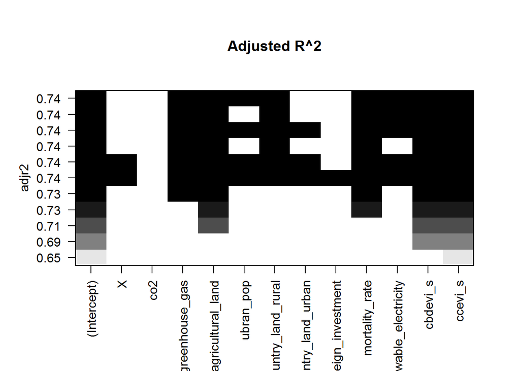

```r
plot(model_forward, scale = "adjr2", main = "Adjusted R^2")
```

```r
#Hybrid stepwise
model_hybrid <- regsubsets(evi_s~., data = final_df,nvmax = 11, nbest = 1, method = "seqrep")

plot(model_hybrid, scale = "adjr2", main = "Adjusted R^2")
summary(model_hybrid)
```

```
## Subset selection object
## Call: regsubsets.formula(evi_s ~ ., data = final_df, nvmax = 11, nbest = 1,
##     method = "seqrep")
## 12 Variables  (and intercept)
##                       Forced in Forced out
## X                         FALSE      FALSE
## co2                       FALSE      FALSE
## greenhouse_gas            FALSE      FALSE
## agricultural_land         FALSE      FALSE
## ubran_pop                 FALSE      FALSE
## country_land_rural        FALSE      FALSE
## country_land_urban        FALSE      FALSE
## foreign_investment        FALSE      FALSE
## mortality_rate            FALSE      FALSE
## renewable_electricity     FALSE      FALSE
## cbdevi_s                  FALSE      FALSE
## ccevi_s                   FALSE      FALSE
## 1 subsets of each size up to 11
## Selection Algorithm: 'sequential replacement'
##           X   co2 greenhouse_gas agricultural_land ubran_pop
## 1  ( 1 )  " " " " " "            " "               " "
## 2  ( 1 )  " " " " " "            " "               " "
## 3  ( 1 )  " " " " " "            "*"               " "
## 4  ( 1 )  " " " " " "            "*"               " "
## 5  ( 1 )  " " " " "*"            "*"               " "
## 6  ( 1 )  " " " " "*"            "*"               " "
## 7  ( 1 )  " " " " "*"            "*"               " "
## 8  ( 1 )  " " " " "*"            "*"               "*"
## 9  ( 1 )  " " " " "*"            "*"               "*"
## 10  ( 1 ) "*" " " "*"            "*"               "*"
## 11  ( 1 ) "*" " " "*"            "*"               "*"
##           country_land_rural country_land_urban foreign_investment
## 1  ( 1 )  " "                " "                " "
## 2  ( 1 )  " "                " "                " "
## 3  ( 1 )  " "                " "                " "
## 4  ( 1 )  " "                " "                " "
## 5  ( 1 )  " "                " "                " "
## 6  ( 1 )  "*"                " "                " "
## 7  ( 1 )  "*"                " "                " "
## 8  ( 1 )  "*"                " "                " "
## 9  ( 1 )  "*"                "*"                " "
## 10  ( 1 ) "*"                "*"                " "
## 11  ( 1 ) "*"                "*"                "*"
##           mortality_rate renewable_electricity cbdevi_s ccevi_s
## 1  ( 1 )  " "            " "                   " "      "*"
## 2  ( 1 )  " "            " "                   "*"      "*"
## 3  ( 1 )  " "            " "                   "*"      "*"
## 4  ( 1 )  "*"            " "                   "*"      "*"
## 5  ( 1 )  "*"            " "                   "*"      "*"
## 6  ( 1 )  "*"            " "                   "*"      "*"
## 7  ( 1 )  "*"            "*"                   "*"      "*"
## 8  ( 1 )  "*"            "*"                   "*"      "*"
## 9  ( 1 )  "*"            "*"                   "*"      "*"
## 10  ( 1 ) "*"            "*"                   "*"      "*"
## 11  ( 1 ) "*"            "*"                   "*"      "*"
```

Based on the insight from the stepwise regressions, we developed Model 3 that Regressed scaled EVI on the following variables:

1. Total GHG Emissions KT
2. Percent of Ag Land
3. Percent of Population in Urban Areas
4. Percent of Rural Land
5. Mortality Rate Under 5 (1000 Births)
6. Renewable electricity output as a percent of total electricity output
7. Biodiversity Sub-Index (CBDEVI)
8. Climate Change Sub-Index (CCEVI)

The following variables were statistically significant in Model 3:

1. Total GHG Emissions KT
2. Percent of Ag Land
3. Mortality Rate Under 5 (1000 Births)
4. Biodiversity Sub-Index (CBDEVI)
5. Climate Change Sub-Index (CCEVI)

Additionally, since we ran a scaled regression where all independent variables were on the same scale, we can see that the variables with the largest estimetd coffecient or effect on the predcited scaled EVI are CCEVI and CBDEVI with the child mortality rate, percent of agricultural labnd, and greenhouse gas emission having much smaller effects. The results suggest that the ability of the natural environment to sustain future ecological shocks are largely a factor of climate change, diversity of the ecosystem, as well as releative economic development, all of which are anthropogenic in nature.

```r
#Running lm model on final_df with vars identified to explain most variation from stepwise
model_3<- lm(evi_s~greenhouse_gas+agricultural_land+ubran_pop+country_land_rural+mortality_rate+renewable_electricity+cbdevi_s+ccevi_s, final_df)


summary(model_3)
```

```
##
## Call:
## lm(formula = evi_s ~ greenhouse_gas + agricultural_land + ubran_pop +
##     country_land_rural + mortality_rate + renewable_electricity +
##     cbdevi_s + ccevi_s, data = final_df)
##
## Residuals:
##      Min       1Q   Median       3Q      Max
## -1.32211 -0.37191  0.01895  0.38364  1.23577
##
## Coefficients:
##                        Estimate Std. Error t value Pr(>|t|)
## (Intercept)            0.004539   0.038736   0.117 0.906866
## greenhouse_gas         0.098431   0.041701   2.360 0.019396 *
## agricultural_land      0.171830   0.042074   4.084 6.82e-05 ***
## ubran_pop             -0.049887   0.046713  -1.068 0.287069
## country_land_rural    -0.066906   0.041382  -1.617 0.107789
## mortality_rate        -0.182398   0.054073  -3.373 0.000921 ***
## renewable_electricity  0.054325   0.045645   1.190 0.235660
## cbdevi_s               0.364680   0.054907   6.642 4.07e-10 ***
## ccevi_s                0.556611   0.061415   9.063 3.08e-16 ***
## ---
## Signif. codes:  0 '***' 0.001 '**' 0.01 '*' 0.05 '.' 0.1 ' ' 1
##
## Residual standard error: 0.5123 on 169 degrees of freedom
## Multiple R-squared:  0.7507, Adjusted R-squared:  0.7389
## F-statistic: 63.62 on 8 and 169 DF,  p-value: < 2.2e-16
```

```r
VIF(model_3)
```

```
## [1] 4.011527
```

```r
anova(model_1, model_2, test="Chisq")
```

```
## Analysis of Variance Table
##
## Model 1: evi_s ~ co2 + greenhouse_gas + agricultural_land + ubran_pop +
##     country_land_rural + country_land_urban + foreign_investment +
##     mortality_rate + renewable_electricity + cbdevi_s + ccevi_s
## Model 2: evi_s ~ agricultural_land + mortality_rate + cbdevi_s + ccevi_s
##   Res.Df   RSS Df Sum of Sq Pr(>Chi)
## 1    166 44.15
## 2    173 47.26 -7   -3.1107    0.111
```

```r
anova(model_1, model_3, test="Chisq")
```

```
## Analysis of Variance Table
##
## Model 1: evi_s ~ co2 + greenhouse_gas + agricultural_land + ubran_pop +
##     country_land_rural + country_land_urban + foreign_investment +
##     mortality_rate + renewable_electricity + cbdevi_s + ccevi_s
## Model 2: evi_s ~ greenhouse_gas + agricultural_land + ubran_pop + country_land_rural +
##     mortality_rate + renewable_electricity + cbdevi_s + ccevi_s
##   Res.Df   RSS Df Sum of Sq Pr(>Chi)
## 1    166 44.15
## 2    169 44.36 -3  -0.20978   0.8522
```

```r
anova(model_2, model_3, test="Chisq")
```

```
## Analysis of Variance Table
##
## Model 1: evi_s ~ agricultural_land + mortality_rate + cbdevi_s + ccevi_s
## Model 2: evi_s ~ greenhouse_gas + agricultural_land + ubran_pop + country_land_rural +
##     mortality_rate + renewable_electricity + cbdevi_s + ccevi_s
##   Res.Df   RSS Df Sum of Sq Pr(>Chi)
## 1    173 47.26
## 2    169 44.36  4    2.9009  0.02599 *
## ---
## Signif. codes:  0 '***' 0.001 '**' 0.01 '*' 0.05 '.' 0.1 ' ' 1
```

6. Reliability of Model

To assess the reliability of the model we calculated the Root Mean Squared Error (RMSE) in addition to estimating the R^2 and the adjusted-R^2 of the model. Additionally we developed confidence intervals for the model.

```r
#Developing RMSE
library(dplyr)
predictions <- predict(model_3,final_df)
head(predictions)
```

```
##          1          2          3          4          5          6
##  0.9465309 -2.0726901  0.4566674 -0.4543160 -0.2358213  2.0334713
```

```r
lm_real_pred <- data.frame(predictions,final_df$evi_s)
head(lm_real_pred)
```

```
##   predictions final_df.evi_s
## 1   0.9465309     -0.3755782
## 2  -2.0726901     -1.6362581
## 3   0.4566674      0.3561235
## 4  -0.4543160     -0.3369995
## 5  -0.2358213     -0.4529636
## 6   2.0334713      2.5686829
```

```r
lm_real_pred <- mutate(lm_real_pred,final_df$evi_s-predictions)
head(lm_real_pred)
```

```
##   predictions final_df.evi_s final_df$evi_s - predictions
## 1   0.9465309     -0.3755782                   -1.3221090
## 2  -2.0726901     -1.6362581                    0.4364320
## 3   0.4566674      0.3561235                   -0.1005439
## 4  -0.4543160     -0.3369995                    0.1173165
## 5  -0.2358213     -0.4529636                   -0.2171423
## 6   2.0334713      2.5686829                    0.5352117
```

```r
names(lm_real_pred) <- c("pred","evi_s","error")
head(lm_real_pred)
```

```
##         pred      evi_s      error
## 1  0.9465309 -0.3755782 -1.3221090
## 2 -2.0726901 -1.6362581  0.4364320
## 3  0.4566674  0.3561235 -0.1005439
## 4 -0.4543160 -0.3369995  0.1173165
## 5 -0.2358213 -0.4529636 -0.2171423
## 6  2.0334713  2.5686829  0.5352117
```

```r
mse <- data.frame(mean((lm_real_pred$error)^2))
print(mse)
```

```
##   mean..lm_real_pred.error..2.
## 1                    0.2492108
```

```r
rmse_model_3 <- sqrt(mse)
print(rmse_model_3)
```

```
##   mean..lm_real_pred.error..2.
## 1                    0.4992102
```

```r
summary(model_3)
```

```
##
## Call:
## lm(formula = evi_s ~ greenhouse_gas + agricultural_land + ubran_pop +
##     country_land_rural + mortality_rate + renewable_electricity +
##     cbdevi_s + ccevi_s, data = final_df)
##
## Residuals:
##      Min       1Q   Median       3Q      Max
## -1.32211 -0.37191  0.01895  0.38364  1.23577
##
## Coefficients:
##                        Estimate Std. Error t value Pr(>|t|)
## (Intercept)            0.004539   0.038736   0.117 0.906866
## greenhouse_gas         0.098431   0.041701   2.360 0.019396 *
## agricultural_land      0.171830   0.042074   4.084 6.82e-05 ***
## ubran_pop             -0.049887   0.046713  -1.068 0.287069
## country_land_rural    -0.066906   0.041382  -1.617 0.107789
## mortality_rate        -0.182398   0.054073  -3.373 0.000921 ***
## renewable_electricity  0.054325   0.045645   1.190 0.235660
## cbdevi_s               0.364680   0.054907   6.642 4.07e-10 ***
## ccevi_s                0.556611   0.061415   9.063 3.08e-16 ***
## ---
## Signif. codes:  0 '***' 0.001 '**' 0.01 '*' 0.05 '.' 0.1 ' ' 1
##
## Residual standard error: 0.5123 on 169 degrees of freedom
## Multiple R-squared:  0.7507, Adjusted R-squared:  0.7389
## F-statistic: 63.62 on 8 and 169 DF,  p-value: < 2.2e-16
```

```r
confint(model_3)
```

```
##                             2.5 %      97.5 %
## (Intercept)           -0.07192959  0.08100672
## greenhouse_gas         0.01610870  0.18075234
## agricultural_land      0.08877121  0.25488931
## ubran_pop             -0.14210289  0.04232922
## country_land_rural    -0.14859812  0.01478625
## mortality_rate        -0.28914389 -0.07565261
## renewable_electricity -0.03578411  0.14443318
## cbdevi_s               0.25628693  0.47307221
## ccevi_s                0.43537132  0.67785122
```

While the model had a fairly high VIF, it was still lower than the rule of thumb of 5. Additionally, since it explained around 74% of the variation in the data and has a reasonable RMSE, we contend that the final model, i.e., Model 3, is reliable.

7. Prediction

While Model 3 allowed us to identify the factors that contribute to EVI, it also allowed us to predict EVI. To do the prediction we enetered the scaled values for the independent variables for Albania and estimated the predicted scaled EVI as well as the predicted EVI.

Albania has an actual EVI of 329. Our model estimated a precited EVI of roughly 335, with a lower bound of 320 and an upper bound of 350. Since the actual EVI falls with in the confidence interval of the predicted EVI, it appers that model produced a fairly accurate predicetd value.

For more predictions, please vist the interactive EVi prediction dashboard at the url: https://public.tableau.com/profile/sadaf8581#!/vizhome/UnderstandingEnvironmentalVulnerability2/EVIPrediction

```r
newdata <- data.frame(greenhouse_gas=(-0.296749833), agricultural_land=(0.222613093), ubran_pop=(-0.544626968259807), country_land_rural=(0.085713184), mortality_rate=(-0.480929187), renewable_electricity=(2.282175968), cbdevi_s=(-0.452116127), ccevi_s=(0.673414477))



newdata
```

```
##   greenhouse_gas agricultural_land ubran_pop country_land_rural
## 1     -0.2967498         0.2226131 -0.544627         0.08571318
##   mortality_rate renewable_electricity   cbdevi_s   ccevi_s
## 1     -0.4809292              2.282176 -0.4521161 0.6734145
```

```r
predicted_scaled_evi<-predict(model_3, newdata, interval="confidence")

predicted_evi=((predicted_scaled_evi*52.16061529)+311.2447753)

predicted_scaled_evi
```

```
##         fit       lwr      upr
## 1 0.4566674 0.1763677 0.736967
```

```r
predicted_evi
```

```
##        fit      lwr      upr
## 1 335.0648 320.4442 349.6854
```

9. Limitations

While the datasets used to answer our research question contained very rich information, each dataset did not contain data for all the same countries which resulted in a sample of 178 countries in the final analytical dataset. Additionally, the datasets contained many missing values which we had to impute. Having data for all countries with non-missing observations would increase the explanatory power of the model and provide consistent results.

Moreover, since the models were run on only 2004 EVI data, which was the only year available, we could only understand the factors behind EVI and predict EVI with data from just one year. Future research studies could develop the EVI scores for additional years based on the guidance provided by SOPAC and estimate a time series model that could likely better predict EVI.

While the scaled regression allows us to compare the effect of each independent variable, all the results are in Z-scores which are not always easy to interpret. Readers should convert the scaled coefficients to their original units to make any meaningful interpretation.

Lastly, while the EVI is a robust and useful measure of environmental vulnerabilty, it is still a composite estimate of a set of sub-indicators and sub-indices. EVI scores coupled with other environmental indicators should be used to holistically assess the ability of the natural environment of a country or region to sustain future ecological shocks.

References

Center for International Earth Science Information Network - CIESIN. (2013). Low Elevation Coastal Zone (LECZ) Urban-Rural Population and Land Area Estimates, Version 2. Retrieved April 9, 2017, from NASA Socio Economic Data and Applications Center (SEDAC): http://dx.doi.org/10.7927/H4MW2F2J

Donner, W., & Rodríguez, H. (2011, January 1). Disaster Risk and Vulnerability: The Role and Impact of Population and Society. Retrieved from Population Reference Bureau: http://www.prb.org/Publications/Articles/2011/disaster-risk.aspx

Gowrie, M. N. (2003). Environmental vulnerability index for the island of Tobago, West Indies. Conservation Ecology 7, 11.

Kaly, U.L.; C.R. Pratt; J. Mitchell. (2004). The Environmental Vulnerability Index (EVI) 2004. New York: SOPAC.

Kouakou, Y. E., Kone, B., Cisse, G., Dje, K. B., N’GO, Y. A., Konare, A. A., & Savane, I. (2013). Environmental vulnerability index: Application to the white bandama bassin in the northern côte D’ivoire. International Journal of Conservation Science, 357-69 .

South Pacific Applied Geoscience Commission - SOPAC; United Nations Environmental Program - UNEP. (2004). Compendium of Environmental Sustainability Indicator Collections: 2004 Environmental Vulnerability Index (EVI). Palisades, NY: NASA Socioeconomic Data and Applications Center (SEDAC).

UN ISDR. (2005). Environment and Vulnerability: Emerging Prospects. Geneva: UNEP. World Bank. (2017, April 9). Climate Change. Retrieved from World Bank: http://data.worldbank.org/topic/climate-change